```python
# import python libraries
import numpy as np
import pandas as pd
import matplotlib as mlt
import matplotlib.pyplot as plt
%matplotlib inline
import seaborn as sns
from textblob import TextBlob
from wordcloud import WordCloud
import re
```

# Data Cleaning

```python
# import csv file
df = pd.read_csv(r"D:\Project\Student Feedback CSV File.csv", encoding= 'unicode_escape')
```

```python
# checking if file has stored or not
df.shape
```

```
(29, 81)
```

```python
# displaying the table
df.head()
```

|  | ï»¿Timestamp | StudentName | RollNumber | Class | Semester | Clarity_Prof_Seema | SubKnowledge_Prof_Seema | Interaction_Prof_Seema | DoubtSolving_Prof_Seema | Punctuality_Prof_Seema | ... | Library_Resources | ClassroomEnvironment | Computer/ITLabWiFi | CleanlinessHygiene | SportsExtracurricular | FacilitiesSuggestions | CollegeExperience | CollegeRecommendation | Fav_Aspects_College | Suggestions |
| --- | --- | --- | --- | --- | --- | --- | --- | --- | --- | --- | --- | --- | --- | --- | --- | --- | --- | --- | --- | --- | --- |
| 0 | 16-08-2025 | Madhura Vahile | 69 | TY | Semester 5 | 4 | 5 | 4 | 5 | 5 | ... | 4 | 5 | 1 | 4 | 1 | NaN | 3 | No | Exit Gate | NaN |
| 1 | 16-08-2025 | Vansh Rathod | 54 | TY | Semester 5 | 4 | 4 | 4 | 2 | 4 | ... | 2 | 3 | 1 | 4 | 2 | 1 Shoes Kyu Nikalne Hai Bha2 Fees Bhara Hai To... | 3 | No | 1 Ke Ise Abhi Bas Ek Hi Saal Aur Jhelna Hai2 D... | Last Year Hai Full Tabahi Machana Hai College Me |
| 2 | 16-08-2025 | Gaurav Bajaj | 4 | TY | Semester 5 | 4 | 3 | 4 | 3 | 3 | ... | 5 | 3 | 3 | 5 | 4 | Please Try To Keep Every Pc Running | 3 | Maybe | Pravin Sir And Leena Mam Who Left Already | NaN |
| 3 | 16-08-2025 | Daneshwari Kaplish | 17 | TY | Semester 5 | 5 | 5 | 5 | 5 | 5 | ... | 3 | 3 | 1 | 4 | 3 | NaN | 3 | Maybe | NaN | 1 Washrooms Need To Be Cleaned And Fresheners ... |
| 4 | 16-08-2025 | Aryan Pol | 50 | TY | Semester 5 | 4 | 5 | 4 | 4 | 4 | ... | 4 | 5 | 2 | 4 | 3 | NaN | 4 | Maybe | NaN | NaN |

5 rows × 81 columns

```python
# Getting column information
df.info()
```

```
<class 'pandas.core.frame.DataFrame'>
RangeIndex: 29 entries, 0 to 28
Data columns (total 81 columns):
 #   Column                           Non-Null Count  Dtype
---  ------                           --------------  -----
 0   ï»¿Timestamp                     29 non-null     object
 1   StudentName                      29 non-null     object
 2   RollNumber                       29 non-null     int64
 3   Class                            29 non-null     object
 4   Semester                         29 non-null     object
 5     Clarity_Prof_Seema             29 non-null     int64
 6     SubKnowledge_Prof_Seema        29 non-null     int64
 7     Interaction_Prof_Seema         29 non-null     int64
 8    DoubtSolving_Prof_Seema         29 non-null     int64
 9     Punctuality_Prof_Seema         29 non-null     int64
```

[output cut: 73 more lines]

```python
# Checking if table contains null or missing values or not
pd.isnull(df)
```

|  | ï»¿Timestamp | StudentName | RollNumber | Class | Semester | Clarity_Prof_Seema | SubKnowledge_Prof_Seema | Interaction_Prof_Seema | DoubtSolving_Prof_Seema | Punctuality_Prof_Seema | ... | Library_Resources | ClassroomEnvironment | Computer/ITLabWiFi | CleanlinessHygiene | SportsExtracurricular | FacilitiesSuggestions | CollegeExperience | CollegeRecommendation | Fav_Aspects_College | Suggestions |
| --- | --- | --- | --- | --- | --- | --- | --- | --- | --- | --- | --- | --- | --- | --- | --- | --- | --- | --- | --- | --- | --- |
| 0 | False | False | False | False | False | False | False | False | False | False | ... | False | False | False | False | False | True | False | False | False | True |
| 1 | False | False | False | False | False | False | False | False | False | False | ... | False | False | False | False | False | False | False | False | False | False |
| 2 | False | False | False | False | False | False | False | False | False | False | ... | False | False | False | False | False | False | False | False | False | True |
| 3 | False | False | False | False | False | False | False | False | False | False | ... | False | False | False | False | False | True | False | False | True | False |
| 4 | False | False | False | False | False | False | False | False | False | False | ... | False | False | False | False | False | True | False | False | True | True |
| 5 | False | False | False | False | False | False | False | False | False | False | ... | False | False | False | False | False | True | False | False | True | True |
| 6 | False | False | False | False | False | False | False | False | False | False | ... | False | False | False | False | False | True | False | False | False | False |
| 7 | False | False | False | False | False | False | False | False | False | False | ... | False | False | False | False | False | True | False | False | True | True |
| 8 | False | False | False | False | False | False | False | False | False | False | ... | False | False | False | False | False | True | False | False | True | True |
| 9 | False | False | False | False | False | False | False | False | False | False | ... | False | False | False | False | False | True | False | False | True | True |
| 10 | False | False | False | False | False | False | False | False | False | False | ... | False | False | False | False | False | False | False | False | False | True |
| 11 | False | False | False | False | False | False | False | False | False | False | ... | False | False | False | False | False | True | False | False | False | False |
| 12 | False | False | False | False | False | False | False | False | False | False | ... | False | False | False | False | False | True | False | False | True | True |
| 13 | False | False | False | False | False | False | False | False | False | False | ... | False | False | False | False | False | False | False | False | False | False |
| 14 | False | False | False | False | False | False | False | False | False | False | ... | False | False | False | False | False | True | False | False | True | True |
| 15 | False | False | False | False | False | False | False | False | False | False | ... | False | False | False | False | False | True | False | False | True | True |
| 16 | False | False | False | False | False | False | False | False | False | False | ... | False | False | False | False | False | True | False | False | True | True |
| 17 | False | False | False | False | False | False | False | False | False | False | ... | False | False | False | False | False | True | False | False | True | True |
| 18 | False | False | False | False | False | False | False | False | False | False | ... | False | False | False | False | False | True | False | False | True | True |
| 19 | False | False | False | False | False | False | False | False | False | False | ... | False | False | False | False | False | True | False | False | True | True |
| 20 | False | False | False | False | False | False | False | False | False | False | ... | False | False | False | False | False | True | False | False | True | True |
| 21 | False | False | False | False | False | False | False | False | False | False | ... | False | False | False | False | False | True | False | False | False | True |
| 22 | False | False | False | False | False | False | False | False | False | False | ... | False | False | False | False | False | True | False | False | True | True |
| 23 | False | False | False | False | False | False | False | False | False | False | ... | False | False | False | False | False | True | False | False | True | True |
| 24 | False | False | False | False | False | False | False | False | False | False | ... | False | False | False | False | False | True | False | False | True | True |
| 25 | False | False | False | False | False | False | False | False | False | False | ... | False | False | False | False | False | True | False | False | True | True |
| 26 | False | False | False | False | False | False | False | False | False | False | ... | False | False | False | False | False | True | False | False | True | True |
| 27 | False | False | False | False | False | False | False | False | False | False | ... | False | False | False | False | False | True | False | False | True | True |
| 28 | False | False | False | False | False | False | False | False | False | False | ... | False | False | False | False | False | True | False | False | True | True |

29 rows × 81 columns

```python
# displaying total null values per column
pd.isnull(df).sum()
```

```
ï»¿Timestamp               0
StudentName                0
RollNumber                 0
Class                      0
Semester                   0
                          ..
FacilitiesSuggestions     25
CollegeExperience          0
CollegeRecommendation      0
Fav_Aspects_College       21
 Suggestions              24
Length: 81, dtype: int64
```

```python
# removing extra spaces of column names
df.columns = df.columns.str.strip()
```

```python
# filling space into null values or missing values of text columns
text_cols = ["FacilitiesSuggestions", "Fav_Aspects_College", "Suggestions"]
df[text_cols] = df[text_cols].fillna("")
```

```python
# checking for null values
pd.isnull(df).sum()
```

```
ï»¿Timestamp             0
StudentName              0
RollNumber               0
Class                    0
Semester                 0
                        ..
FacilitiesSuggestions    0
CollegeExperience        0
CollegeRecommendation    0
Fav_Aspects_College      0
Suggestions              0
Length: 81, dtype: int64
```

```python
# getting column names
df.columns
```

```
Index(['ï»¿Timestamp', 'StudentName', 'RollNumber', 'Class', 'Semester',
       'Clarity_Prof_Seema', 'SubKnowledge_Prof_Seema',
       'Interaction_Prof_Seema', 'DoubtSolving_Prof_Seema',
       'Punctuality_Prof_Seema', 'Comments_Prof_Seema', 'Clarity_Prof_Ashwini',
       'SubKnowledge_Prof_Ashwini', 'Interaction_Prof_Ashwini',
       'DoubtSolving_Prof_Ashwini', 'Punctuality_Prof_Ashwini',
       'Comments_Prof_Ashwini', 'Clarity_Mrs_Vaishali',
       'SubKnowledge_Mrs_Vaishali', 'Interaction_Mrs_Vaishali',
       'DoubtSolving_Mrs_Vaishali', 'Punctuality_Mrs_Vaishali',
       'Comments_Mrs_Vaishali', 'Clarity_Mrs_Anita', 'SubKnowledge_Mrs_Anita',
       'Interaction_Mrs_Anita', 'DoubtSolving_Mrs_Anita',
       'Punctuality_Mrs_Anita', 'Comments_Mrs_Anita', 'Clarity_Mrs_Sakshi',
       'SubKnowledge_Mrs_Sakshi', 'Interaction_Mrs_Sakshi',
       'DoubtSolving_Mrs_Sakshi', 'Punctuality_Mrs_Sakshi',
       'Comments_Mrs_Sakshi', 'Clarity_Mrs_Sonam', 'SubKnowledge_Mrs_Sonam',
       'Interaction_Mrs_Sonam', 'DoubtSolving_Mrs_Sonam',
       'Punctuality_Mrs_Sonam', 'Comments_Mrs_Sonam', 'Clarity_Mr_Pradosh',
       'SubKnowledge_Mr_Pradosh', 'Interaction_Mr_Pradosh',
       'DoubtSolving_Mr_Pradosh', 'Punctuality_Mr_Pradosh',
       'Comments_Mr_Pradosh', 'Clarity_Ms_Rupali', 'SubKnowledge_Ms_Rupali',
       'Interaction_Ms_Rupali', 'DoubtSolving_Ms_Rupali',
       'Punctuality_Ms_Rupali', 'Comments_Ms_Rupali', 'Clarity_Ms_Maitri',
       'SubKnowledge_Ms_Maitri', 'Interaction_Ms_Maitri',
       'DoubtSolving_Ms_Maitri', 'Punctuality_Ms_Maitri', 'Comments_Ms_Maitri',
       'Clarity_Mrs_Priya', 'SubKnowledge_Mrs_Priya', 'Interaction_Mrs_Priya',
       'DoubtSolving_Mrs_Priya', 'Punctuality_Mrs_Priya', 'Comments_Mrs_Priya',
       'Clarity_Ms_Abha', 'SubKnowledge_Ms_Abha', 'Interaction_Ms_Abha',
       'DoubtSolving_Ms_Abha', 'Punctuality_Ms_Abha', 'Comments_Ms_Abha',
       'Library_Resources', 'ClassroomEnvironment', 'Computer/ITLabWiFi',
       'CleanlinessHygiene', 'SportsExtracurricular', 'FacilitiesSuggestions',
       'CollegeExperience', 'CollegeRecommendation', 'Fav_Aspects_College',
       'Suggestions'],
      dtype='object')
```

```python
# statistical calculations for numeric values
df[['Clarity_Prof_Seema', 'SubKnowledge_Prof_Seema','Interaction_Prof_Seema', 'DoubtSolving_Prof_Seema',
       'Punctuality_Prof_Seema', 'Clarity_Prof_Ashwini','SubKnowledge_Prof_Ashwini', 'Interaction_Prof_Ashwini',
       'DoubtSolving_Prof_Ashwini', 'Punctuality_Prof_Ashwini', 'Clarity_Mrs_Vaishali','SubKnowledge_Mrs_Vaishali', 'Interaction_Mrs_Vaishali',
       'DoubtSolving_Mrs_Vaishali', 'Punctuality_Mrs_Vaishali','Clarity_Mrs_Anita', 'SubKnowledge_Mrs_Anita','Interaction_Mrs_Anita', 'DoubtSolving_Mrs_Anita',
       'Punctuality_Mrs_Anita',  'Clarity_Mrs_Sakshi','SubKnowledge_Mrs_Sakshi', 'Interaction_Mrs_Sakshi',
       'DoubtSolving_Mrs_Sakshi', 'Punctuality_Mrs_Sakshi','Clarity_Mrs_Sonam', 'SubKnowledge_Mrs_Sonam',
       'Interaction_Mrs_Sonam', 'DoubtSolving_Mrs_Sonam','Punctuality_Mrs_Sonam',  'Clarity_Mr_Pradosh','SubKnowledge_Mr_Pradosh', 'Interaction_Mr_Pradosh',
       'DoubtSolving_Mr_Pradosh', 'Punctuality_Mr_Pradosh','Clarity_Ms_Rupali', 'SubKnowledge_Ms_Rupali','Interaction_Ms_Rupali', 'DoubtSolving_Ms_Rupali',
       'Punctuality_Ms_Rupali',  'Clarity_Ms_Maitri','SubKnowledge_Ms_Maitri', 'Interaction_Ms_Maitri','DoubtSolving_Ms_Maitri', 'Punctuality_Ms_Maitri',
       'Clarity_Mrs_Priya', 'SubKnowledge_Mrs_Priya', 'Interaction_Mrs_Priya',
       'DoubtSolving_Mrs_Priya', 'Punctuality_Mrs_Priya', 'Clarity_Ms_Abha', 'SubKnowledge_Ms_Abha', 'Interaction_Ms_Abha',
       'DoubtSolving_Ms_Abha', 'Punctuality_Ms_Abha', 'Library_Resources', 'ClassroomEnvironment', 'Computer/ITLabWiFi','CleanlinessHygiene', 'SportsExtracurricular', 'FacilitiesSuggestions',
       'CollegeExperience',
       ]].describe()
```

|  | Clarity_Prof_Seema | SubKnowledge_Prof_Seema | Interaction_Prof_Seema | DoubtSolving_Prof_Seema | Punctuality_Prof_Seema | Clarity_Prof_Ashwini | SubKnowledge_Prof_Ashwini | Interaction_Prof_Ashwini | DoubtSolving_Prof_Ashwini | Punctuality_Prof_Ashwini | ... | SubKnowledge_Ms_Abha | Interaction_Ms_Abha | DoubtSolving_Ms_Abha | Punctuality_Ms_Abha | Library_Resources | ClassroomEnvironment | Computer/ITLabWiFi | CleanlinessHygiene | SportsExtracurricular | CollegeExperience |
| --- | --- | --- | --- | --- | --- | --- | --- | --- | --- | --- | --- | --- | --- | --- | --- | --- | --- | --- | --- | --- | --- |
| count | 29.000000 | 29.000000 | 29.000000 | 29.000000 | 29.000000 | 29.000000 | 29.000000 | 29.000000 | 29.000000 | 29.000000 | ... | 29.000000 | 28.000000 | 29.000000 | 29.000000 | 29.000000 | 29.000000 | 29.000000 | 29.000000 | 29.000000 | 29.000000 |
| mean | 4.379310 | 4.310345 | 4.206897 | 4.137931 | 4.275862 | 3.896552 | 4.034483 | 3.689655 | 3.896552 | 4.034483 | ... | 3.689655 | 3.571429 | 3.689655 | 3.724138 | 3.310345 | 3.655172 | 3.068966 | 3.586207 | 2.758621 | 3.448276 |
| std | 0.902924 | 1.003688 | 0.901559 | 1.059789 | 0.959782 | 0.939028 | 0.944259 | 0.967451 | 1.012240 | 0.905647 | ... | 1.137147 | 1.136224 | 1.168132 | 1.065583 | 1.198316 | 0.813979 | 1.360962 | 1.086187 | 1.327058 | 0.736120 |
| min | 1.000000 | 1.000000 | 1.000000 | 1.000000 | 1.000000 | 1.000000 | 1.000000 | 1.000000 | 1.000000 | 2.000000 | ... | 1.000000 | 1.000000 | 1.000000 | 1.000000 | 1.000000 | 3.000000 | 1.000000 | 1.000000 | 1.000000 | 2.000000 |
| 25% | 4.000000 | 4.000000 | 4.000000 | 4.000000 | 4.000000 | 3.000000 | 4.000000 | 3.000000 | 3.000000 | 3.000000 | ... | 3.000000 | 3.000000 | 3.000000 | 3.000000 | 3.000000 | 3.000000 | 2.000000 | 3.000000 | 2.000000 | 3.000000 |
| 50% | 5.000000 | 5.000000 | 4.000000 | 4.000000 | 5.000000 | 4.000000 | 4.000000 | 4.000000 | 4.000000 | 4.000000 | ... | 4.000000 | 3.000000 | 4.000000 | 4.000000 | 4.000000 | 3.000000 | 3.000000 | 4.000000 | 3.000000 | 3.000000 |
| 75% | 5.000000 | 5.000000 | 5.000000 | 5.000000 | 5.000000 | 5.000000 | 5.000000 | 4.000000 | 5.000000 | 5.000000 | ... | 5.000000 | 5.000000 | 5.000000 | 5.000000 | 4.000000 | 4.000000 | 4.000000 | 4.000000 | 4.000000 | 4.000000 |
| max | 5.000000 | 5.000000 | 5.000000 | 5.000000 | 5.000000 | 5.000000 | 5.000000 | 5.000000 | 5.000000 | 5.000000 | ... | 5.000000 | 5.000000 | 5.000000 | 5.000000 | 5.000000 | 5.000000 | 5.000000 | 5.000000 | 5.000000 | 5.000000 |

8 rows × 61 columns

# Exploratory Data Analysis

### combining columns per teacher

```python
teacher_name = "Prof_Seema"

# Rating columns for this teacher
rating_cols_Prof_Seema = [col for col in df.columns if teacher_name in col and not col.startswith("Comments_")]

print("Rating Columns:", rating_cols_Prof_Seema)
```

```
Rating Columns: ['Clarity_Prof_Seema', 'SubKnowledge_Prof_Seema', 'Interaction_Prof_Seema', 'DoubtSolving_Prof_Seema', 'Punctuality_Prof_Seema']
```

```python
teacher_name = "Mrs_Sonam"

# Rating columns for this teacher
rating_cols_Mrs_Sonam = [col for col in df.columns if teacher_name in col and not col.startswith("Comments_")]

print("Rating Columns:", rating_cols_Mrs_Sonam)
```

```
Rating Columns: ['Clarity_Mrs_Sonam', 'SubKnowledge_Mrs_Sonam', 'Interaction_Mrs_Sonam', 'DoubtSolving_Mrs_Sonam', 'Punctuality_Mrs_Sonam']
```

```python
teacher_name = "Mrs_Anita"

# Rating columns for this teacher
rating_cols_Mrs_Anita = [col for col in df.columns if teacher_name in col and not col.startswith("Comments_")]

print("Rating Columns:", rating_cols_Mrs_Anita)
```

```
Rating Columns: ['Clarity_Mrs_Anita', 'SubKnowledge_Mrs_Anita', 'Interaction_Mrs_Anita', 'DoubtSolving_Mrs_Anita', 'Punctuality_Mrs_Anita']
```

```python
teacher_name = "Prof_Ashwini"

# Rating columns for this teacher
rating_cols_Prof_Ashwini = [col for col in df.columns if teacher_name in col and not col.startswith("Comments_")]

print("Rating Columns:", rating_cols_Prof_Ashwini)
```

```
Rating Columns: ['Clarity_Prof_Ashwini', 'SubKnowledge_Prof_Ashwini', 'Interaction_Prof_Ashwini', 'DoubtSolving_Prof_Ashwini', 'Punctuality_Prof_Ashwini']
```

```python
teacher_name = "Mrs_Sakshi"

# Rating columns for this teacher
rating_cols_Mrs_Sakshi = [col for col in df.columns if teacher_name in col and not col.startswith("Comments_")]

print("Rating Columns:", rating_cols_Mrs_Sakshi)
```

```
Rating Columns: ['Clarity_Mrs_Sakshi', 'SubKnowledge_Mrs_Sakshi', 'Interaction_Mrs_Sakshi', 'DoubtSolving_Mrs_Sakshi', 'Punctuality_Mrs_Sakshi']
```

```python
teacher_name = "Mr_Pradosh"

# Rating columns for this teacher
rating_cols_Mr_Pradosh = [col for col in df.columns if teacher_name in col and not col.startswith("Comments_")]

print("Rating Columns:", rating_cols_Mr_Pradosh)
```

```
Rating Columns: ['Clarity_Mr_Pradosh', 'SubKnowledge_Mr_Pradosh', 'Interaction_Mr_Pradosh', 'DoubtSolving_Mr_Pradosh', 'Punctuality_Mr_Pradosh']
```

```python
teacher_name = "Ms_Maitri"

# Rating columns for this teacher
rating_cols_Ms_Maitri = [col for col in df.columns if teacher_name in col and not col.startswith("Comments_")]

print("Rating Columns:", rating_cols_Ms_Maitri)
```

```
Rating Columns: ['Clarity_Ms_Maitri', 'SubKnowledge_Ms_Maitri', 'Interaction_Ms_Maitri', 'DoubtSolving_Ms_Maitri', 'Punctuality_Ms_Maitri']
```

```python
teacher_name = "Mrs_Priya"

# Rating columns for this teacher
rating_cols_Mrs_Priya = [col for col in df.columns if teacher_name in col and not col.startswith("Comments_")]

print("Rating Columns:", rating_cols_Mrs_Priya)
```

```
Rating Columns: ['Clarity_Mrs_Priya', 'SubKnowledge_Mrs_Priya', 'Interaction_Mrs_Priya', 'DoubtSolving_Mrs_Priya', 'Punctuality_Mrs_Priya']
```

```python
teacher_name = "Ms_Abha"

# Rating columns for this teacher
rating_cols_Ms_Abha = [col for col in df.columns if teacher_name in col and not col.startswith("Comments_")]

print("Rating Columns:", rating_cols_Ms_Abha)
```

```
Rating Columns: ['Clarity_Ms_Abha', 'SubKnowledge_Ms_Abha', 'Interaction_Ms_Abha', 'DoubtSolving_Ms_Abha', 'Punctuality_Ms_Abha']
```

```python
teacher_name = "Ms_Rupali"

# Rating columns for this teacher
rating_cols_Ms_Rupali = [col for col in df.columns if teacher_name in col and not col.startswith("Comments_")]

print("Rating Columns:", rating_cols_Ms_Rupali)
```

```
Rating Columns: ['Clarity_Ms_Rupali', 'SubKnowledge_Ms_Rupali', 'Interaction_Ms_Rupali', 'DoubtSolving_Ms_Rupali', 'Punctuality_Ms_Rupali']
```

```python
teacher_name = "Mrs_Vaishali"

# Rating columns for this teacher
rating_cols_Mrs_Vaishali = [col for col in df.columns if teacher_name in col and not col.startswith("Comments_")]

print("Rating Columns:", rating_cols_Mrs_Vaishali)
```

```
Rating Columns: ['Clarity_Mrs_Vaishali', 'SubKnowledge_Mrs_Vaishali', 'Interaction_Mrs_Vaishali', 'DoubtSolving_Mrs_Vaishali', 'Punctuality_Mrs_Vaishali']
```

### For Average Rating

```python
# Create a dictionary: teacher_name -> rating columns list
teacher_ratings = {
    "Prof_Seema": rating_cols_Prof_Seema,
    "Mrs_Sonam": rating_cols_Mrs_Sonam,
    "Mrs_Anita": rating_cols_Mrs_Anita,
    "Prof_Ashwini": rating_cols_Prof_Ashwini,
    "Mrs_Sakshi": rating_cols_Mrs_Sakshi,
    "Mr_Pradosh": rating_cols_Mr_Pradosh,
    "Ms_Maitri": rating_cols_Ms_Maitri,
    "Mrs_Priya": rating_cols_Mrs_Priya,
    "Ms_Abha": rating_cols_Ms_Abha,
    "Ms_Rupali": rating_cols_Ms_Rupali,
    "Mrs_Vaishali": rating_cols_Mrs_Vaishali,
}

# Dictionary to store each teacher's DataFrame
teacher_dfs = {}

print(teacher_ratings)
```

```
{'Prof_Seema': ['Clarity_Prof_Seema', 'SubKnowledge_Prof_Seema', 'Interaction_Prof_Seema', 'DoubtSolving_Prof_Seema', 'Punctuality_Prof_Seema'], 'Mrs_Sonam': ['Clarity_Mrs_Sonam', 'SubKnowledge_Mrs_Sonam', 'Interaction_Mrs_Sonam', 'DoubtSolving_Mrs_Sonam', 'Punctuality_Mrs_Sonam'], 'Mrs_Anita': ['Cl…
```

```python
# Dictionary to store each teacher's DataFrame
teacher_dfs = {}

for teacher, rating_cols in teacher_ratings.items():
    # Create DataFrame with only rating columns
    teacher_df = df[rating_cols].copy()

    # Store in dictionary
    teacher_dfs[teacher] = teacher_df
```

```python
# Prof Seema's ratings only
teacher_dfs['Prof_Seema'].head(20)
```

|  | Clarity_Prof_Seema | SubKnowledge_Prof_Seema | Interaction_Prof_Seema | DoubtSolving_Prof_Seema | Punctuality_Prof_Seema |
| --- | --- | --- | --- | --- | --- |
| 0 | 4 | 5 | 4 | 5 | 5 |
| 1 | 4 | 4 | 4 | 2 | 4 |
| 2 | 4 | 3 | 4 | 3 | 3 |
| 3 | 5 | 5 | 5 | 5 | 5 |
| 4 | 4 | 5 | 4 | 4 | 4 |
| 5 | 1 | 1 | 1 | 1 | 1 |
| 6 | 5 | 5 | 5 | 5 | 5 |
| 7 | 5 | 5 | 5 | 5 | 5 |
| 8 | 5 | 5 | 4 | 5 | 5 |
| 9 | 4 | 4 | 4 | 4 | 4 |
| 10 | 4 | 4 | 4 | 4 | 4 |
| 11 | 5 | 5 | 5 | 5 | 5 |
| 12 | 5 | 5 | 5 | 5 | 5 |
| 13 | 4 | 4 | 4 | 4 | 4 |
| 14 | 5 | 5 | 5 | 5 | 5 |
| 15 | 5 | 5 | 5 | 5 | 5 |
| 16 | 5 | 5 | 5 | 5 | 5 |
| 17 | 3 | 3 | 3 | 3 | 3 |
| 18 | 5 | 5 | 5 | 5 | 5 |
| 19 | 5 | 5 | 5 | 5 | 5 |

```python
#Initialize a dictionary to store averages
avg_ratings = {}
#Loop through each teacher’s DataFrame
for teacher, t_df in teacher_dfs.items():
    # Compute overall average rating for this teacher
    avg_ratings[teacher] = t_df.mean().mean()
#View results
for teacher, avg in avg_ratings.items():
    print(f"{teacher}: {avg:.2f}")
```

```
Prof_Seema: 4.26
Mrs_Sonam: 2.95
Mrs_Anita: 3.63
Prof_Ashwini: 3.91
Mrs_Sakshi: 4.15
Mr_Pradosh: 4.02
Ms_Maitri: 3.64
Mrs_Priya: 3.93
Ms_Abha: 3.67
Ms_Rupali: 3.84
Mrs_Vaishali: 3.96
```

```python
#Convert to DataFrame for easier plotting
avg_ratings_df = pd.DataFrame(list(avg_ratings.items()),columns=['Teacher','Average_Rating'])
avg_ratings_df
```

|  | Teacher | Average_Rating |
| --- | --- | --- |
| 0 | Prof_Seema | 4.262069 |
| 1 | Mrs_Sonam | 2.950246 |
| 2 | Mrs_Anita | 3.633744 |
| 3 | Prof_Ashwini | 3.910345 |
| 4 | Mrs_Sakshi | 4.153448 |
| 5 | Mr_Pradosh | 4.021182 |
| 6 | Ms_Maitri | 3.635760 |
| 7 | Mrs_Priya | 3.930049 |
| 8 | Ms_Abha | 3.666010 |
| 9 | Ms_Rupali | 3.839409 |
| 10 | Mrs_Vaishali | 3.963547 |

# Visualizing Average Ratings

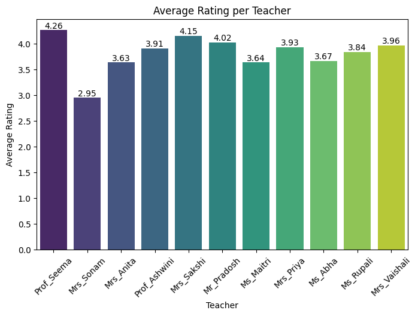

```python
plt.figure(figsize=(8,5))
ax = sns.barplot(x="Teacher",y="Average_Rating",data=avg_ratings_df,palette='viridis')
plt.title("Average Rating per Teacher")
plt.ylabel("Average Rating")
plt.xticks(rotation=45)


# Add data labels on top of each bar
for bars in ax.containers:
    ax.bar_label(bars,fmt='%.2f')

plt.show()
```

- Prof. Seema has the highest average rating among all teachers, which indicates strong student satisfaction with her teaching.

## Calculating Average Rating per Category for Each Teacher

```python
for teacher, t_df in teacher_dfs.items():
    if not t_df.empty:  # Only process if teacher has rating columns
        # Average per category
        avg_per_category = t_df.mean()

        # Display the averages
        print(f"\nAverage ratings for {teacher}:\n", avg_per_category)
```

```
Average ratings for Prof_Seema:
 Clarity_Prof_Seema         4.379310
SubKnowledge_Prof_Seema    4.310345
Interaction_Prof_Seema     4.206897
DoubtSolving_Prof_Seema    4.137931
Punctuality_Prof_Seema     4.275862
dtype: float64

Average ratings for Mrs_Sonam:
 Clarity_Mrs_Sonam         2.862069
SubKnowledge_Mrs_Sonam    3.034483
Interaction_Mrs_Sonam     2.785714
DoubtSolving_Mrs_Sonam    2.965517
Punctuality_Mrs_Sonam     3.103448
dtype: float64

Average ratings for Mrs_Anita:
 Clarity_Mrs_Anita         3.551724
SubKnowledge_Mrs_Anita    3.586207
Interaction_Mrs_Anita     3.892857
DoubtSolving_Mrs_Anita    3.586207
Punctuality_Mrs_Anita     3.551724
dtype: float64

Average ratings for Prof_Ashwini:
 Clarity_Prof_Ashwini         3.896552
SubKnowledge_Prof_Ashwini    4.034483
Interaction_Prof_Ashwini     3.689655
DoubtSolving_Prof_Ashwini    3.896552
Punctuality_Prof_Ashwini     4.034483
dtype: float64

Average ratings for Mrs_Sakshi:
 Clarity_Mrs_Sakshi         4.068966
SubKnowledge_Mrs_Sakshi    4.172414
Interaction_Mrs_Sakshi     4.250000
DoubtSolving_Mrs_Sakshi    4.068966
Punctuality_Mrs_Sakshi     4.206897
dtype: float64

```

[output cut: 32 more lines]

```
Average ratings for Ms_Rupali:
 Clarity_Ms_Rupali         3.689655
SubKnowledge_Ms_Rupali    3.965517
Interaction_Ms_Rupali     3.714286
DoubtSolving_Ms_Rupali    3.965517
Punctuality_Ms_Rupali     3.862069
dtype: float64

Average ratings for Mrs_Vaishali:
 Clarity_Mrs_Vaishali         3.931034
SubKnowledge_Mrs_Vaishali    4.172414
Interaction_Mrs_Vaishali     3.714286
DoubtSolving_Mrs_Vaishali    3.758621
Punctuality_Mrs_Vaishali     4.241379
dtype: float64
```

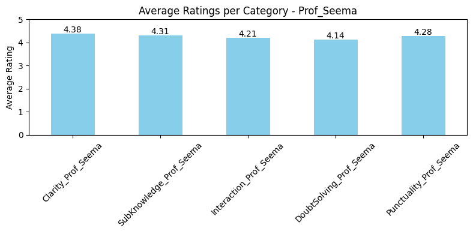

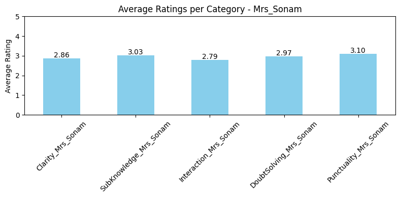

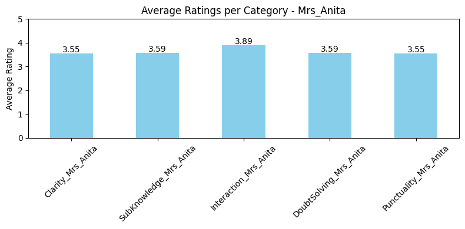

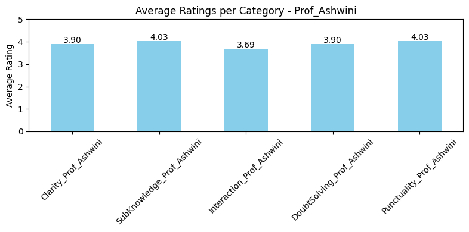

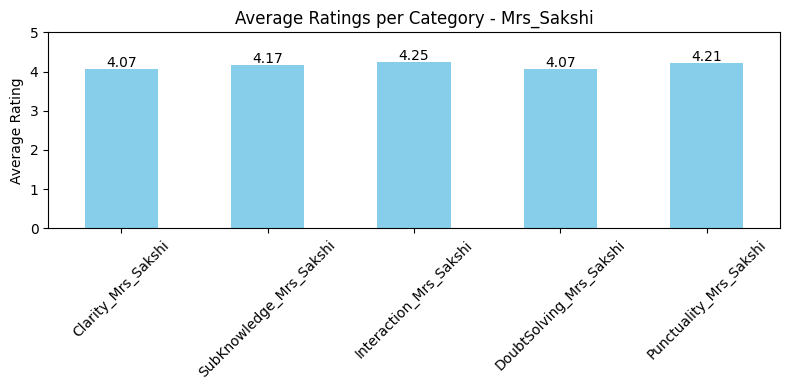

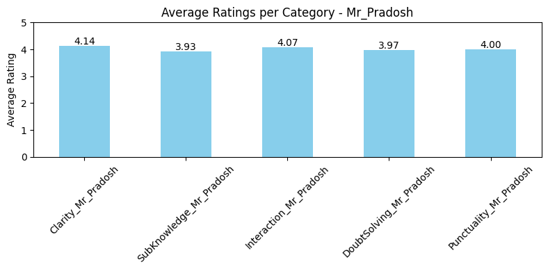

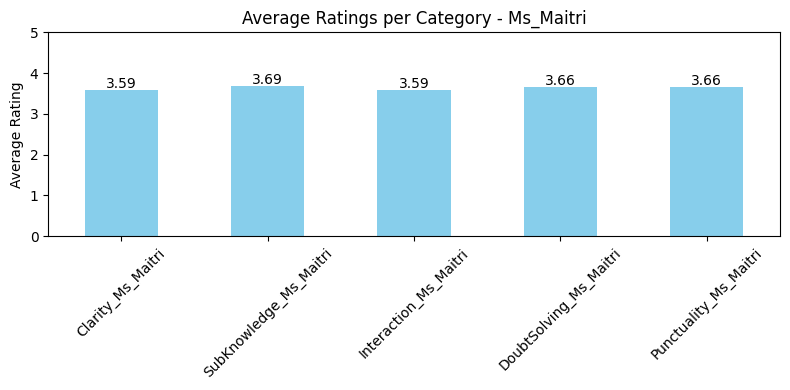

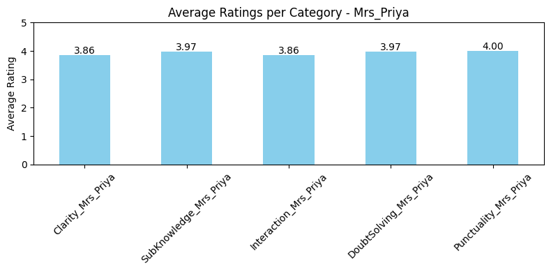

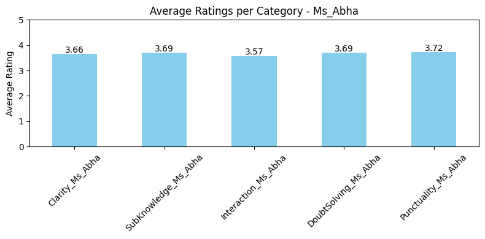

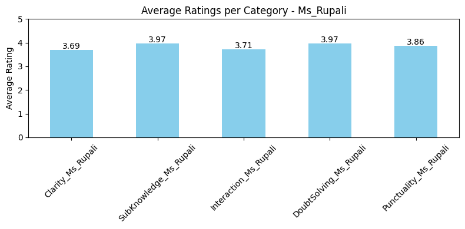

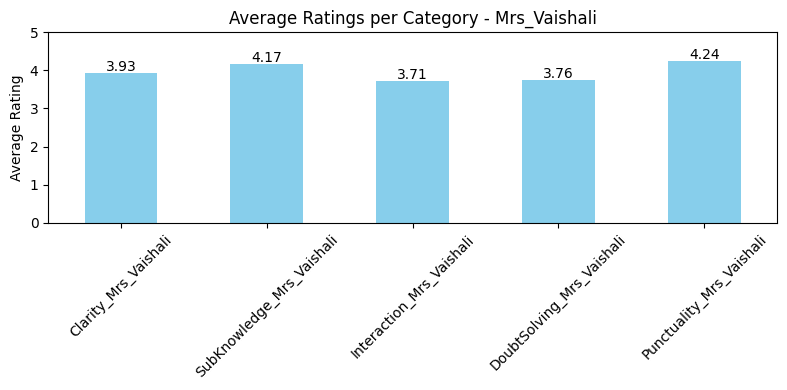

```python
for teacher, t_df in teacher_dfs.items():
    if not t_df.empty:
        avg_per_category = t_df.mean()

        # Plot
        plt.figure(figsize=(8,4))
        avg_per_category.plot(kind='bar', color='skyblue')
        plt.title(f"Average Ratings per Category - {teacher}")
        plt.ylabel("Average Rating")
        plt.ylim(0,5)  # Assuming rating scale 0-5
        plt.xticks(rotation=45)

        # Add data labels on top
        for i, v in enumerate(avg_per_category):
            plt.text(i, v + 0.05, f"{v:.2f}", ha='center', fontsize=10)

        plt.tight_layout()
        plt.show()
```

- Prof. Seema and Ms. Sakshi show consistent excellence with ratings above 4 across all categories, reflecting strong overall teaching quality. In contrast, Ms. Sonam’s ratings are mostly below 3, indicating student dissatisfaction across multiple aspects.

## Calculating Average Rating per Teacher for Each Category

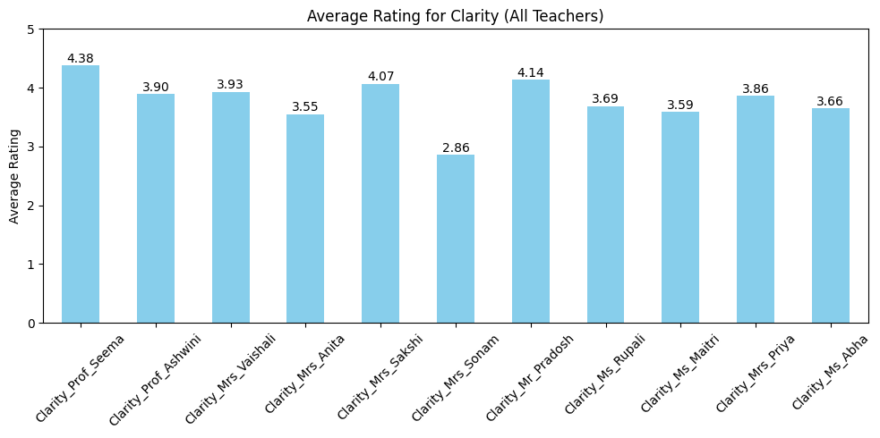

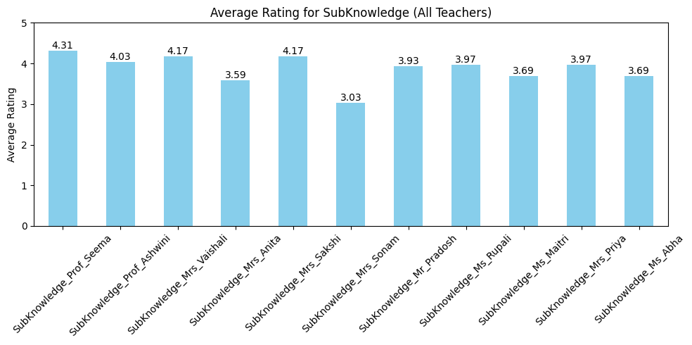

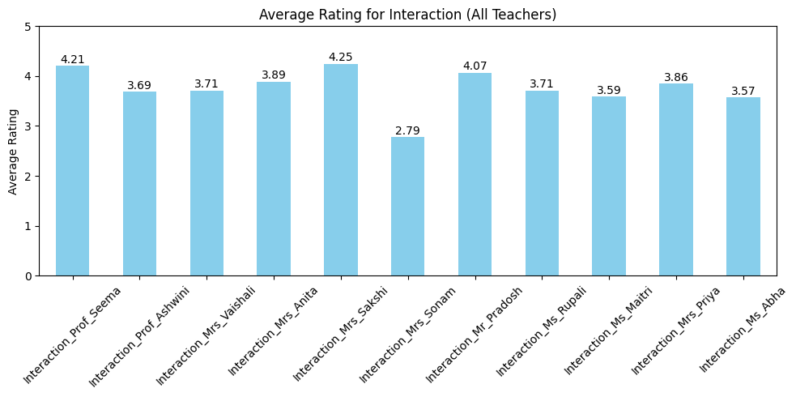

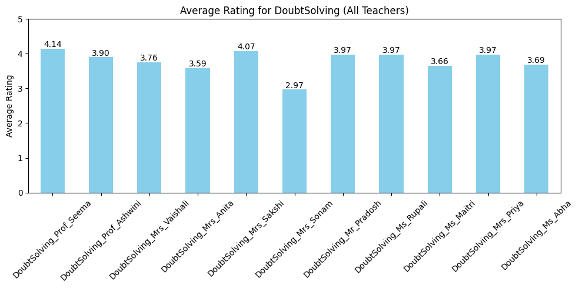

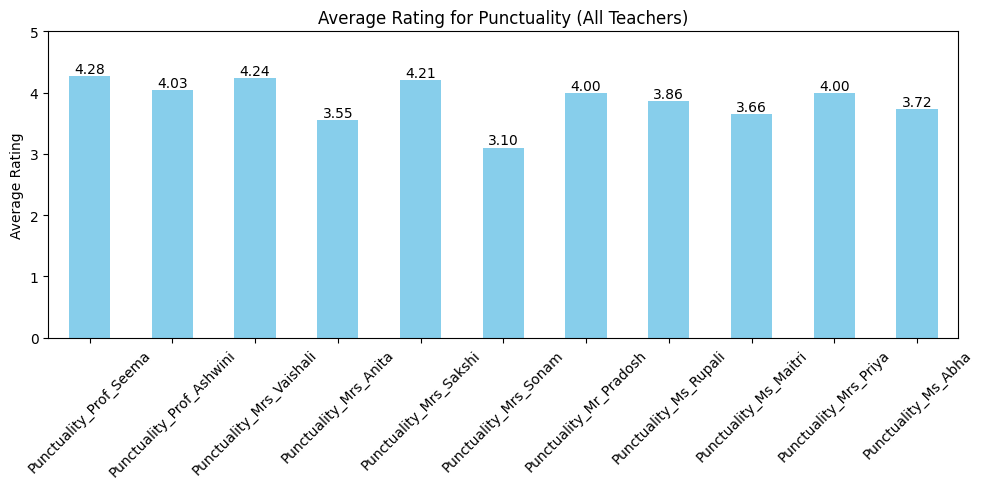

```python
categories = ["Clarity", "SubKnowledge", "Interaction", "DoubtSolving", "Punctuality"]

for cat in categories:
    cat_cols = [col for col in df.columns if col.startswith(cat)]
    cat_avg = df[cat_cols].mean()

    plt.figure(figsize=(10,5))
    cat_avg.plot(kind='bar', color='skyblue')
    plt.title(f"Average Rating for {cat} (All Teachers)")
    plt.ylabel("Average Rating")
    plt.ylim(0,5)
    plt.xticks(rotation=45)

    for i, v in enumerate(cat_avg):
        plt.text(i, v + 0.05, f"{v:.2f}", ha='center', fontsize=10)

    plt.tight_layout()
    plt.show()
```

- Prof. Seema leads in most categories, showing excellence in subject knowledge, doubt solving, and punctuality, making her the top-performing teacher overall. Mr. Prashosh, Prof. Ashwini, and Ms. Sakshi perform strongly in specific areas like subject knowledge and interaction, reflecting their unique strengths. Ms. Sakshi particularly excels in interaction, highlighting her strong student engagement compared to peers.

# Top 3 Teachers

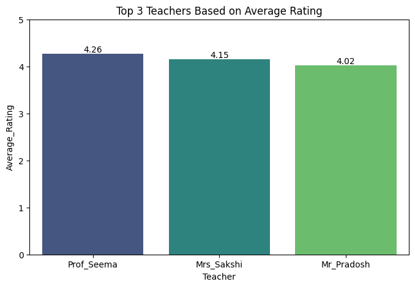

```python
#: Sort and get top 3 teachers
top3_teachers = avg_ratings_df.sort_values(by="Average_Rating",ascending=False).head(3)
top3_teachers

#Visualize top 3 teachers
plt.figure(figsize=(8,5))
ax = sns.barplot(x="Teacher",y="Average_Rating",data=top3_teachers,palette='viridis')
plt.title("Top 3 Teachers Based on Average Rating")
plt.ylim(0,5)

#adding data labels
for bars in ax.containers:
    ax.bar_label(bars,fmt="%.2f")

plt.show()
```

## Visualizing Distribution per Facility

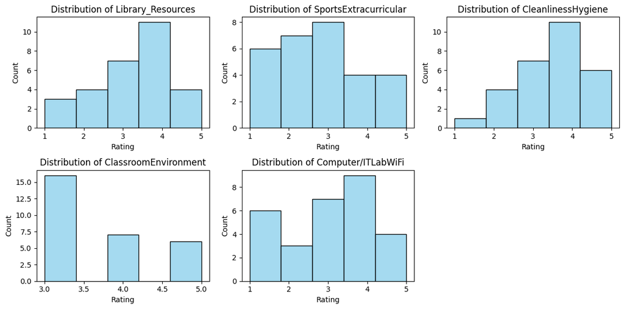

```python
import matplotlib.pyplot as plt
import seaborn as sns

facilities = ['Library_Resources','SportsExtracurricular','CleanlinessHygiene','ClassroomEnvironment','Computer/ITLabWiFi']

plt.figure(figsize=(12,6))
for i, col in enumerate(facilities,1):
    plt.subplot(2,3,i)
    sns.histplot(df[col], bins=5, kde=False, color='skyblue')
    plt.title(f'Distribution of {col}')
    plt.xlabel('Rating')
    plt.ylabel('Count')
plt.tight_layout()
plt.show()
```

## Boxplots to Check Spread and Outliers for Facilities

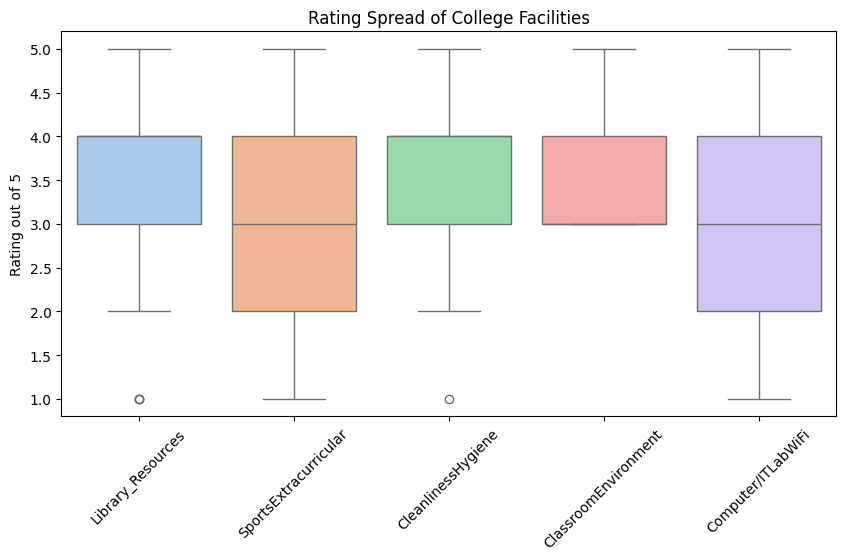

```python
plt.figure(figsize=(10,5))
sns.boxplot(data=df[facilities], palette='pastel')
plt.title("Rating Spread of College Facilities")
plt.ylabel("Rating out of 5")
plt.xticks(rotation=45)
plt.show()
```

- Sports and extracurricular activities show high variability in ratings, indicating mixed student opinions, while classroom environment ratings are consistent, reflecting general agreement on its quality.

## Average Rating per Facility

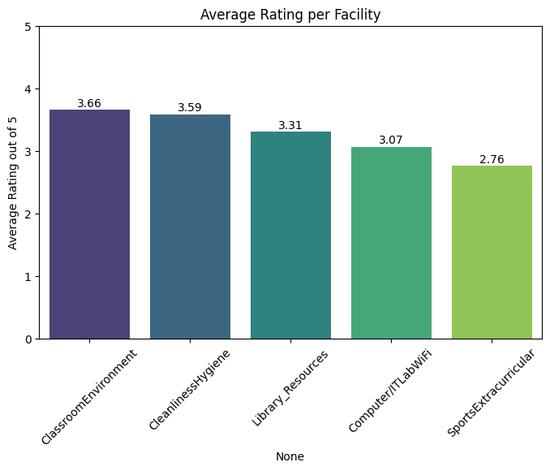

```python
avg_facility_rating = df[facilities].mean().sort_values(ascending=False)
avg_facility_rating


plt.figure(figsize=(8,5))
sns.barplot(x=avg_facility_rating.index, y=avg_facility_rating.values, palette='viridis')
plt.title("Average Rating per Facility")
plt.ylabel("Average Rating out of 5")
plt.ylim(0,5)

# Add data labels
for i, v in enumerate(avg_facility_rating.values):
    plt.text(i, v + 0.05, f"{v:.2f}", ha='center', fontsize=10)

plt.xticks(rotation=45)
plt.show()
```

- Classroom environment has the highest average rating, followed by cleanliness and hygiene, while sports and extracurricular activities receive the lowest, highlighting strong academic facilities but weaker extracurricular support.

## Grouped Analysis for Library Resources

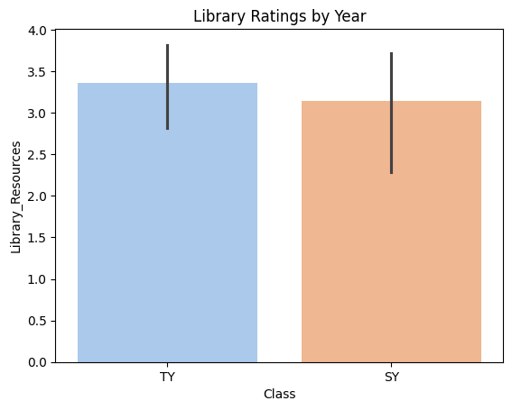

```python
sns.barplot(x='Class', y='Library_Resources', data=df, palette='pastel')
plt.title("Library Ratings by Year")
plt.show()
```

- Library resources are rated slightly higher by TY students compared to SY students, indicating that senior students find the resources more adequate or accessible.

## College Experience

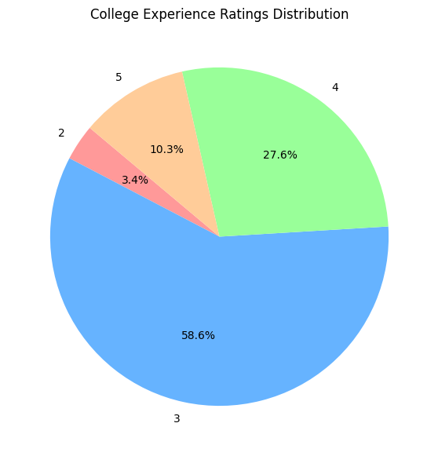

```python
# Count number of students per rating
rating_counts = df['CollegeExperience'].value_counts().sort_index()
rating_counts

plt.figure(figsize=(7,7))
plt.pie(rating_counts,
        labels=rating_counts.index,
        autopct='%1.1f%%',   # shows percentage
        startangle=140,      # rotates chart for better view
        colors=['#ff9999','#66b3ff','#99ff99','#ffcc99','#c2c2f0'])

plt.title("College Experience Ratings Distribution")
plt.show()
```

- Most students have an average perception of their college experience, with a notable portion rating it positively, while very few express dissatisfaction, indicating generally moderate satisfaction.

## Sentiment analysis for College Experience

```python
#Create a new column for sentiment
```

```python
def experience_sentiment(rating):
    if rating <= 2:
        return 'Negative'
    elif rating == 3:
        return 'Neutral'
    else:  # 4 or 5
        return 'Positive'

# Apply function to the column
df['College_Experience_Sentiment'] = df['CollegeExperience'].apply(experience_sentiment)

# Check result
df[['CollegeExperience','College_Experience_Sentiment']].head(10)
```

|  | CollegeExperience | College_Experience_Sentiment |
| --- | --- | --- |
| 0 | 3 | Neutral |
| 1 | 3 | Neutral |
| 2 | 3 | Neutral |
| 3 | 3 | Neutral |
| 4 | 4 | Positive |
| 5 | 3 | Neutral |
| 6 | 5 | Positive |
| 7 | 4 | Positive |
| 8 | 3 | Neutral |
| 9 | 3 | Neutral |

```python
#Count Positive / Neutral / Negative
```

```python
sentiment_counts = df['College_Experience_Sentiment'].value_counts()
sentiment_counts
```

```
College_Experience_Sentiment
Neutral     17
Positive    11
Negative     1
Name: count, dtype: int64
```

## Visualizing sentiment (Pie Chart)

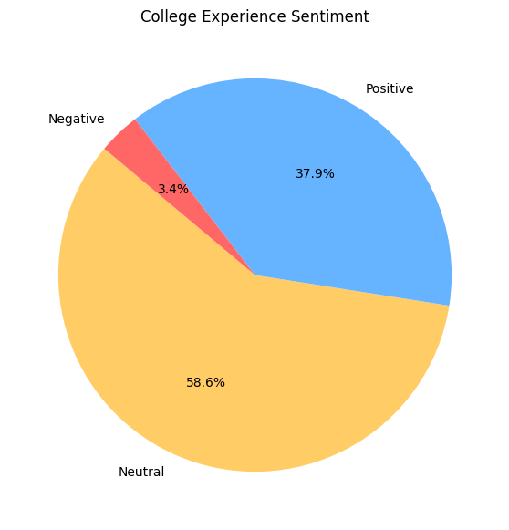

```python
import matplotlib.pyplot as plt

plt.figure(figsize=(7,7))
plt.pie(sentiment_counts,
        labels=sentiment_counts.index,
        autopct='%1.1f%%',
        startangle=140,
        colors=['#ffcc66','#66b3ff','#ff6666']
        )  # Negative, Neutral, Positive


plt.title("College Experience Sentiment")
plt.show()
```

- Most students have a neutral college experience, a significant portion report a positive experience, and very few express a negative experience, indicating overall satisfactory student perception.

## Overview of Recommendation Data

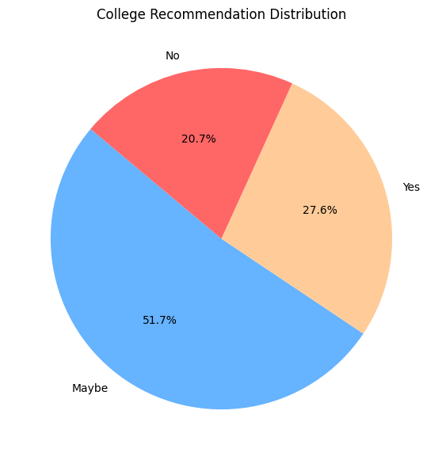

```python
# Count how many students gave each response
recommendation_counts = df['CollegeRecommendation'].value_counts()
recommendation_counts

recommendation_percentage = df['CollegeRecommendation'].value_counts(normalize=True) * 100
recommendation_percentage

plt.figure(figsize=(7,7))
plt.pie(recommendation_counts,
        labels=recommendation_counts.index,
        autopct='%1.1f%%',
        startangle=140,
        colors=['#66b3ff','#ffcc99','#ff6666'])  # Yes, Maybe, No
plt.title("College Recommendation Distribution")
plt.show()
```

- Most students are uncertain about recommending the college, with a majority choosing "maybe," some saying "yes," and a smaller portion saying "no," indicating mixed perceptions about endorsing the college.

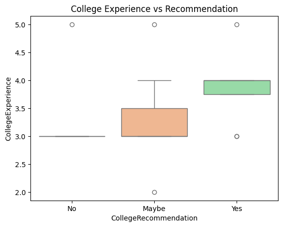

```python
# Example: College Experience vs Recommendation
sns.boxplot(x='CollegeRecommendation', y='CollegeExperience', data=df, palette='pastel')
plt.title("College Experience vs Recommendation")
plt.show()
```

- Most students are uncertain about recommending the college, with a majority choosing "maybe," some saying "yes," and a smaller portion saying "no," indicating mixed perceptions about endorsing the college.